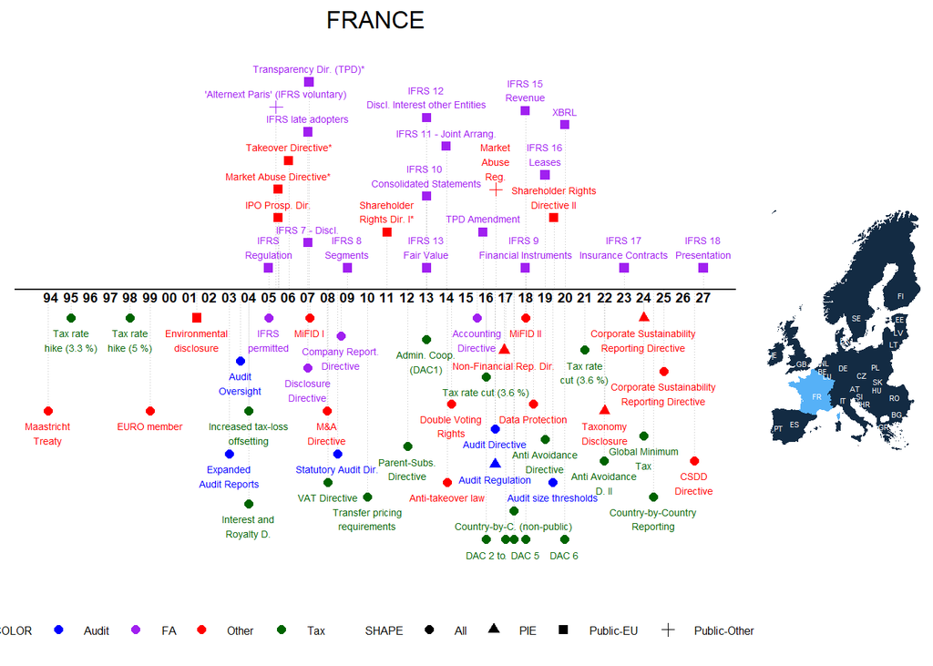

Notes: The graph depicts major regulatory changes that we identified via an extensive literature search, an online survey of mentioned authors, and other sources. Please note that the graph does not include all possible regulatory changes, e.g. minor revisions to local GAAP or tax rate changes below 3% are not included. The dates of EU Directives are based on the official transposition deadlines unless denoted with a *, in which case we included the entry-to-force date as identified in the literature. For more information, please go to [Labro and Pierk (2023)](http://www.eu-regulations.com/Labro_Pierk_2023.pdf). We kindly ask that you cite the paper if you use the information on this website in your research project. Do you have comments or see anything missing? Please email us!

## Regulations, Publications, Further Graphs

The tab ‘Regulations’ includes links to the regulations, gives short descriptions, and provides selective papers for further reading. If the regulation is a national transposition of an EU Directive, the link to the Directive is given. The tab ‘Number of Regulations’ shows graphically the number of regulations 8 years around the respective year (-4,-3,-2,-1,0,+1,+2,+3). The tab ‘Number of Categories” shows graphically the number of different categories 8 years around the respective year (-4,-3,-2,-1,0,+1,+2,+3). The tab ’Publications’ shows all publications that include the countries’ names and variations thereof in the title, abstract, or keywords. Similarly, the tab ‘SSRN’ shows papers of the SSRN Accouning Research Network that include the countries’ names and variations.

### Regulations

[output not shown]

[output cut: 57 more lines]

### Number of Regulations

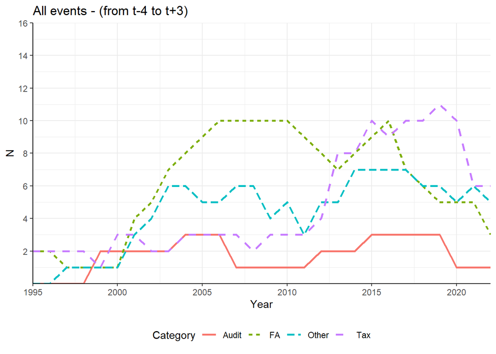

### Number of Categories

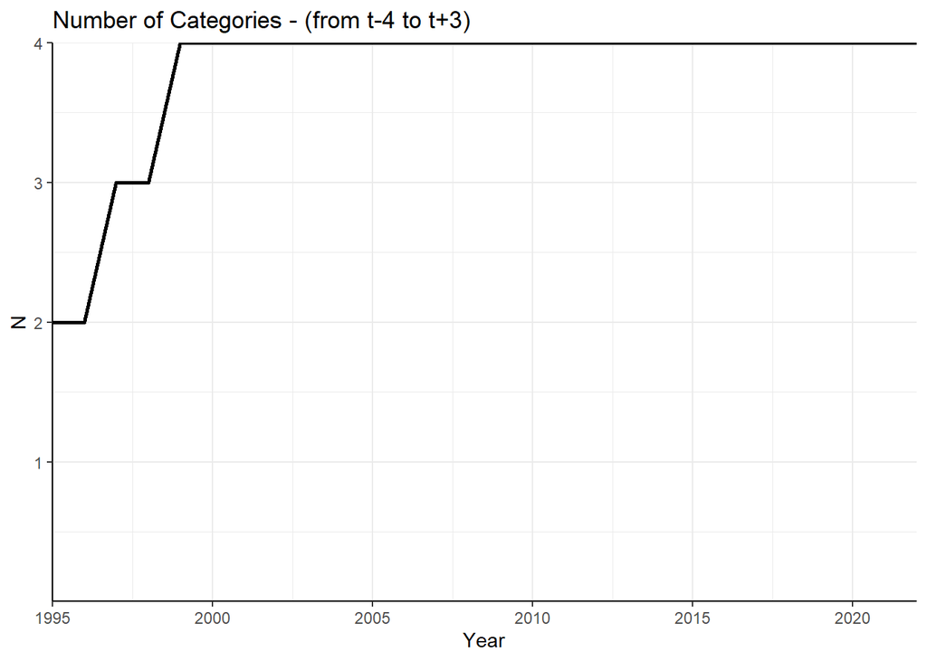

### Publications

|  | authors | title | year | journal |
| --- | --- | --- | --- | --- |
| 1 | Bonsón E., Lavorato D., Lamboglia R., Mancini D. | artificial intelligence activities and ethical approaches in leading listed companies in the european union | 2021 | International Journal of Accounting Information Systems |
| 2 | Cazenave B., Morales J. | ngo responses to financial evaluation: auditability, purification and performance | 2021 | Accounting, Auditing and Accountability Journal |
| 3 | Kohlhase S., Pierk J. | tax rule changes and the timing of asset write-offs in loss firms | 2021 | Journal of Business Finance and Accounting |
| 4 | McBride K. | a french connection; paths to a ‘new system’ of accounting for the royal navy in 1832 | 2021 | British Accounting Review |
| 5 | Morinière A., Georgescu I. | hybridity and the use of performance measurement: facilitating compromises or creating moral struggles? insights from healthcare organizations | 2021 | Accounting, Auditing and Accountability Journal |
| 6 | Ndemewah S.R., Hiebl M.R.W. | management accounting research on africa | 2021 | European Accounting Review |
| 7 | Anantavrasilp S., de Jong A., DeJong D.V., Hege U. | blockholder leverage and payout policy: evidence from french holding companies | 2020 | Journal of Business Finance and Accounting |
| 8 | Belze L., Larmande F., Schneider L. | transaction costs, option prices, and model risk in fair value accounting | 2020 | European Accounting Review |
| 9 | Christensen M., Rocher S. | the persistence of accountant beancounter images in popular culture | 2020 | Accounting, Auditing and Accountability Journal |
| 10 | Di Cimbrini T., Funnell W., Bigoni M., Migliori S., Consorti A. | accounting for napoleonic imperialism in tuscany and the kingdom of naples | 2020 | Accounting, Auditing and Accountability Journal |

[output cut: 169 more lines]

### SSRN

|  | authors | title | Posted | Revised |
| --- | --- | --- | --- | --- |
| 1 | H. David Rosenbloom and Fadi Shaheen | toulouse: no treaty-based credit? | 2021-11-23 |  |
| 2 | Laurence Jacquet and Etienne Lehmann | how to tax different incomes? | 2021-09-22 | 2021-11-09 |
| 3 | Shivaram Rajgopal | has european corporatism delivered? a survey with preliminary evidence | 2021-09-21 |  |
| 4 | Chibuzo Amadi and Zhou Zhu | the effect of mandatory corporate social responsibility (csr) disclosure on corporate financial performance in china: a did analysis | 2021-09-14 |  |
| 5 | Tim Loughran | reconsidering equity issue performance: a focused criticism of the fama-french factor models | 2021-09-07 | 2021-10-22 |
| 6 | Cédric Poretti | an empirical examination of relative valuation of publicly listed firms using french gaap after ifrs adoption | 2021-07-24 |  |
| 7 | Peterson K Ozili | bank earnings management using loan loss provisions: comparing the uk, france, south africa and egypt | 2021-07-21 |  |
| 8 | Karama Saadaoui | the impact of board characteristics on the financial performance of french firms | 2021-05-27 |  |
| 9 | Thomas Ruf, Jun Song and Bohui Zhang | political relations and media coverage | 2021-05-25 |  |
| 10 | Hani El-Chaarani | ownership structure and performance of listed family firms in france | 2021-05-25 |  |

[output cut: 20 more lines]